# Psy 350: HW 2

# Clear environment

```r
rm(list=ls())
```

# load libraries

```r
library(tidyverse)
library(psych)
library(car)
library(effsize)
```

# Read in data

```r
setwd("C:/Users/Neil/Desktop/Class folder/Fall 2018/Psy_350/Data")
yetz.data <- read.csv("PSY 350 Class Survey.csv", header = TRUE, stringsAsFactors = FALSE)
names(yetz.data)
```

```
 [1] "id"         "gender"     "hand"       "year"       "siblings"   "age"        "gpa"        "interest"   "grad"       "firstmajor" "travel"     "height"     "smartphone" "paidwork"
[15] "photos"     "neatness"   "time"       "coffee"     "study"      "swls_1"     "swls_2"     "swls_3"     "swls_4"     "swls_5"     "cons_1"     "cons_2"     "cons_3"     "cons_4"
[29] "cons_5"     "cons_6"     "cons_7"     "cons_8"     "cons_9"     "cons_50"    "stats"      "honesty"
```

# Q1

What is the level of measurement for each of your variables?

```r
class(yetz.data$coffe)
```

```
[1] "integer"
```

```r
class(yetz.data$firstmajor)
```

```
[1] "character"
```

```r
class(yetz.data$swls_1)
```

```
[1] "integer"
```

Coffee consumption - ratio

Psychology as first major - nominal

Satisfaction with life - interval

# Q2

For the ‘firstmajor’ variable, what proportion of students fall in each category? (Give your answer as a decimal, not a percentage)

```r
prop.table(table(yetz.data$firstmajor))
```

```
                   no        yes
0.01098901 0.45054945 0.53846154
```

# Q3

What are the mean, standard deviation, and skewness for:

```r
yetz.data$swl<- rowMeans(yetz.data[, 20:24], na.rm = TRUE)
describe(yetz.data$coffee)
```

```
   vars  n mean   sd median trimmed  mad min max range skew kurtosis   se
X1    1 91 4.15 4.84      3    3.37 4.45   0  28    28  1.8     4.95 0.51
```

```r
describe(yetz.data$swl)
```

```
   vars  n mean   sd median trimmed  mad min max range  skew kurtosis   se
X1    1 90 4.77 1.22      5    4.86 1.19 1.6 6.8   5.2 -0.67    -0.36 0.13
```

Coffee consumption:

Mean: 4.15 SD: 4.84

Skew: 1.8

Satisfaction with life (averaged across all 5 items):

Mean: 4.77 SD: 1.22

Skew: -0.67

# Q4

```
[1] 52  7
```

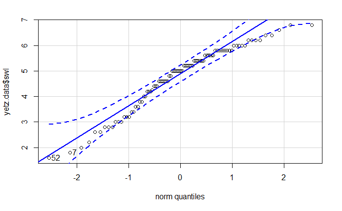

```r
qqPlot(yetz.data$swl)
```

```r
t.test(yetz.data$coffee, mu = 11.2)
```

```
    One Sample t-test

data:  yetz.data$coffee
t = -13.876, df = 90, p-value < 2.2e-16
alternative hypothesis: true mean is not equal to 11.2
95 percent confidence interval:
 3.145021 5.162671
sample estimates:
mean of x
 4.153846
```

# Q7

Calculate and report Cohen’s d.

```r
(mean(yetz.data$coffee, na.rm = TRUE) - 11.2)/sd(yetz.data$coffee, na.rm = TRUE)
```

```
[1] -1.454595
```

# Q8

Do students who chose psychology as their first major report, on average, higher or lower satisfaction with life than students who changed their major to psychology? Test this hypothesis. Use an alpha level of .05.

```r
yetz.data <- yetz.data %>% filter(firstmajor != "")
t.test(yetz.data$swl ~ yetz.data$firstmajor, var.equal = TRUE)
```

```
    Two Sample t-test

data:  yetz.data$swl by yetz.data$firstmajor
t = 0.324, df = 87, p-value = 0.7467
alternative hypothesis: true difference in means is not equal to 0
95 percent confidence interval:
 -0.4380071  0.6086194
sample estimates:
 mean in group no mean in group yes
         4.820000          4.734694
```

# Q9

Report:

the value you obtained for your test statistic *0.324* degrees of freedom *87* p-value, rounded to 2 decimal places as discussed in the tutorial. .75

# Q10

Calculate and report Cohen’s d.

```r
effsize::cohen.d(yetz.data$swl, yetz.data$firstmajor, na.rm = TRUE, pooled = TRUE)
```

```
Cohen's d

d estimate: -0.06832683 (negligible)
95 percent confidence interval:
       inf        sup
-0.4919924  0.3553387
```

# Q11

This is a: *very small effect* small effect medium effect large effect